# Session 8: Matrix Factorization & Learned Embeddings

> *"Last week we hand-built the vectors. Today the model learns them — and we prove they're good."*

**Core idea:** stop hand-crafting features. Decompose the rating matrix so that every user and every item becomes a **learned vector in one shared space** — an *embedding*.

## Recap: content-based filtering (Session 7)

Describe each **item by its features** (genre columns), build a **user profile** from what they liked, rank by **cosine similarity**.

- ✅ No other users needed — works day one, handles new items.
- ⚠️ Stuck with hand-crafted features; every "Drama" gets the **identical** vector.

Today's **learned** vectors fix that.

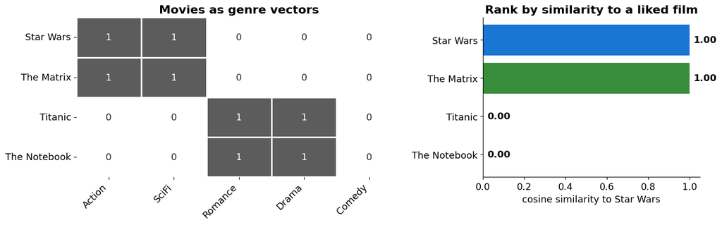

```
Content-based needs no other users — but it only sees the features we hand-craft.
```

## Recap: collaborative filtering

Forget item features — **collaborative filtering** predicts from the **crowd**, using only the user × item **rating matrix** and people who behaved like you.

- **User-based:** find users who rated like *you*, borrow their opinions.
- **Item-based:** find items rated alike, recommend the neighbours.

> *"Birds of a feather flock together."* Today we make it **model-based** — **learn** from that matrix instead of looking up neighbours each query.

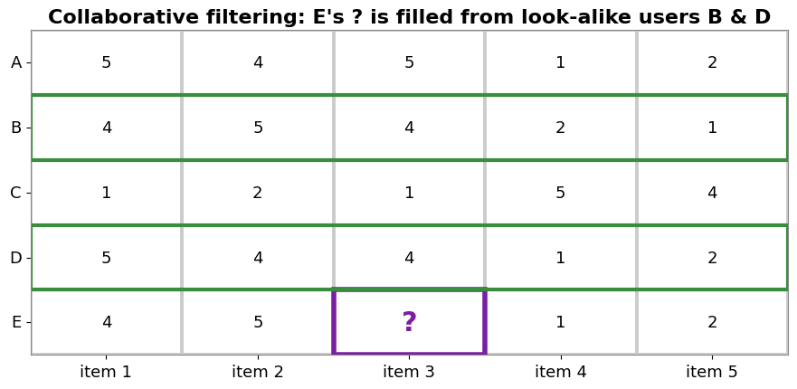

```
CF uses only the rating matrix — who rated similarly — never the movie content.
```

## A quick look: Bayes for binary ratings

Treat a missing cell as **classification**: will user *D* like item 2 (+1) or not (−1)? Use the ratings we *do* have, via **Bayes' rule**:

$$P(x_2 = +1 \mid x_1=-1,\, x_3=+1)\;\propto\; P(x_1=-1,\,x_3=+1 \mid x_2=+1)\,\cdot\, P(x_2=+1)$$

Interpretable, and it works — but it returns **a probability for one cell**. Run it for every item and you just refill D's **row of $R$** — never a **reusable vector** to cluster or search. That's what today fixes.

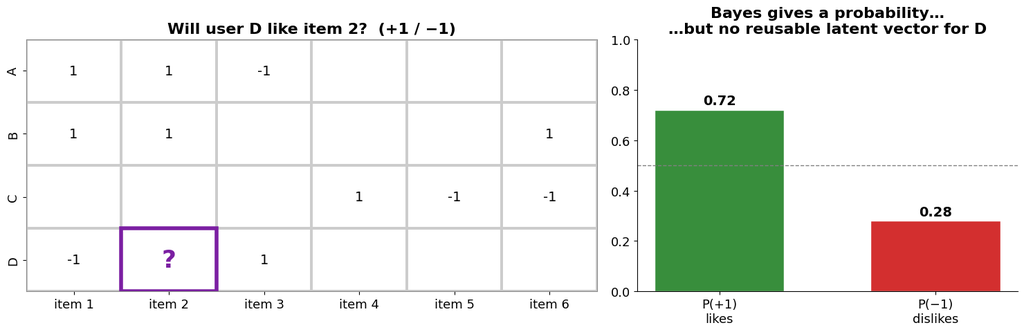

```
Predicting one cell at a time is fine — but it never produces a reusable representation.
```

## Recap: how do we *measure* a recommender? ROC & AUROC

Call an item **relevant** if the user rated it ≥ 4. A model outputs a **score** per item; sweep a threshold and trace **true-positive rate vs false-positive rate** → the **ROC curve**.

$$\textbf{AUROC} \;=\; P\big(\text{a random relevant item scores above a random irrelevant one}\big)$$

- **0.5** = coin flip (the diagonal) · **1.0** = perfect ranking.
- One number to compare *any* two methods — here a dumb **popularity** baseline already clears chance.

*(AUROC scores **ranking**. Today we predict the actual rating *value*, so the final scoreboard uses **RMSE** — average prediction error — instead. Same idea: one number, lower is better.)*

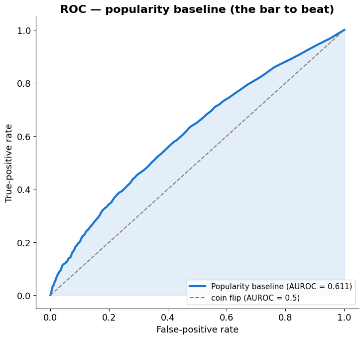

```
Popularity already beats chance (0.611) — popular movies tend to be rated higher.
```

## Today: from predicting cells to learning vectors

**Bayes** showed road 1 of model-based CF: predict one missing cell from $R$. It works — but hands back *a number, no reusable vector*. There's a second road:

1. **Predict the cell directly** — Bayes · kNN. A number, no vector. *(just saw it)*
2. **Learn a vector per user & item** — SVD, gradient descent, autoencoders → **embeddings**. ← **today**

Road 2 lets the model discover the structure in $R$ and hands us vectors we can **reuse, search, transfer**.

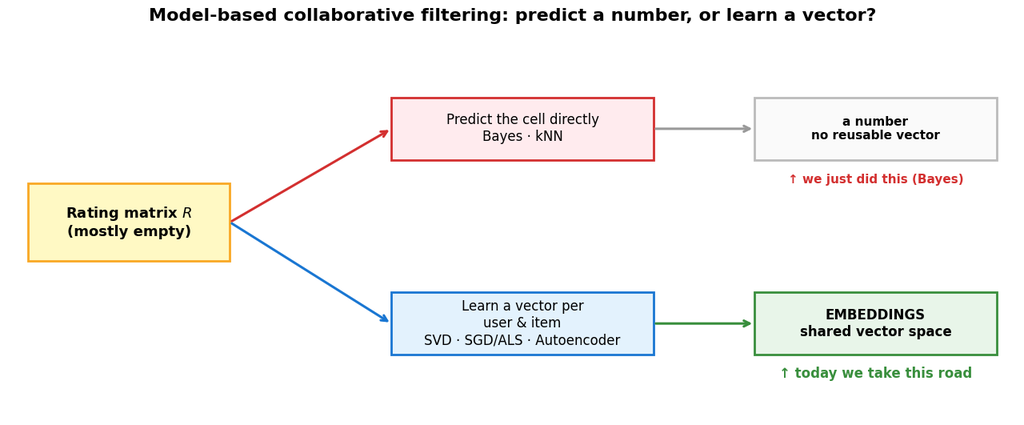

## First, the key idea: dimension reduction

A movie described by **all its genres** is long and *redundant* — sci-fi/action/adventure/fantasy move together; romance/drama/musical/family too. Those columns really live on a **few underlying axes**.

That's **$k$**: the number of **hidden factors** we keep. Squeeze a high-dimensional, correlated description down to $k$ coordinates that carry the signal — users get the same treatment, in the **same** space.

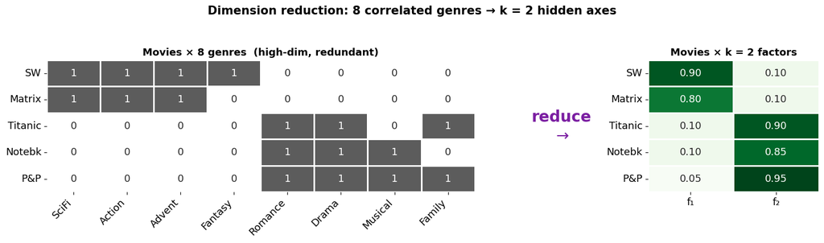

```
f₁ ≈ "action/sci-fi", f₂ ≈ "romance/drama". k = how many axes we keep — that is the whole point of k.
```

## The leap: one shared latent space

The Bayes/kNN road builds a **fresh predictor for each user from that user's own row** — nothing is shared, nothing is reused. Instead, learn **one vector per user** and **one vector per item** in the **same** $k$-dimensional space, so that

$$R \;\approx\; P \cdot Q^{T}, \qquad r_{ui} \;\approx\; \vec{p}_u \cdot \vec{q}_i$$

- $P$ = user factors ($m$ users × $k$) · $Q$ = item factors ($n$ items × $k$), with $k \ll m, n$.
- A hidden factor $f_1$ might mean "action-vs-romance", $f_2$ "blockbuster-vs-arthouse" — but **the model discovers them**.

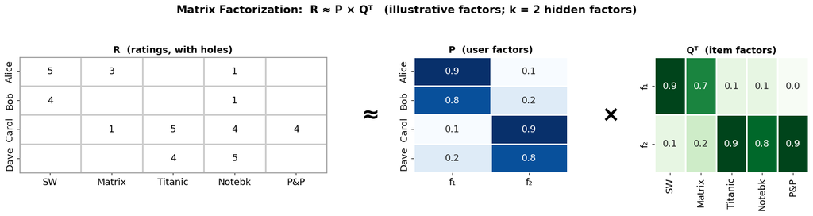

```
Illustrative taste-weights in [0,1]: their dot products reproduce the high→low PATTERN of the ratings (e.g. Alice·SW = 0.82 high, Alice·Titanic = 0.18 low). The exact factors come from SVD next.
```

## SVD, geometrically: every matrix is *rotate → stretch → rotate*

A matrix times a vector is a **linear transformation** — it moves points around space. Remarkable fact: *any* linear map, however messy, is just **a rotation, then a stretch along the axes, then another rotation** (more precisely, $U,V$ are *orthogonal* — rotation, possibly with a reflection). **SVD writes exactly that:**

$$M \;=\; U\,\Sigma\,V^{T}\qquad\quad V^{T}=\text{rotate},\;\; \Sigma=\text{stretch},\;\; U=\text{rotate}$$

The stretch factors are the **singular values** $\sigma_k$ — *how much* each new axis is stretched = how much **signal** that direction carries.

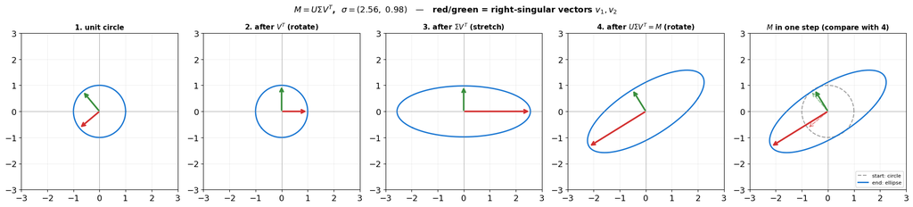

```
Σ stretches along the singular axes: |Mv₁|=σ₁, |Mv₂|=σ₂ — the arrows ARE the ellipse axes.
```

## Where do U, Σ, V come from? (it's PCA, twice)

You met **PCA**: find the orthogonal directions of greatest variance — the **eigenvectors of the covariance matrix**. SVD is PCA run on *both sides* of $R$ at once:

- $V$ = eigenvectors of $R^{T}R$ → the **item–item** matrix (which items co-vary)
- $U$ = eigenvectors of $R R^{T}$ → the **user–user** matrix (which users co-vary)
- $\Sigma=\sqrt{\text{eigenvalues}}$ → the **signal strength** of each shared direction (largest first)

Both sides share the *same* axes — that is *why* users and items land in **one** space.

*(Strictly, $R^{T}R$ is the covariance only once $R$ is **mean-centred**; on raw ratings it's the uncentered scatter matrix — same eigenvectors idea. We subtract the mean $\mu$ a couple of slides on.)*

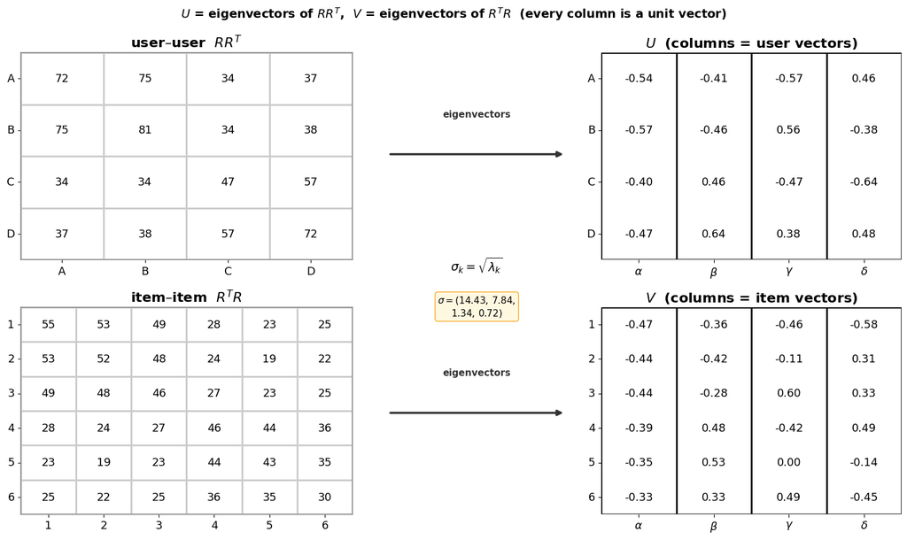

```
Columns are unit length:  ‖U cols‖ = [1. 1. 1. 1.]  and orthonormal (UᵀU = I): True
```

## A full example: decompose, then drop the weak axes

Our toy $R$ (4 users × 6 items) has **two clear groups** — A,B love items 1–3, C,D love 4–6 — so its SVD has **two big singular values and two tiny ones**. Keep the top **2** triplets → the **best** rank-2 approximation (Eckart–Young): a faithful $R_2$ at small **Frobenius** error $\lVert R - R_2\rVert$.

> 🧠 **Same trick today:** **LoRA** fine-tunes huge LLMs by freezing the big weight matrix and learning only a small **low-rank update** $A B^{T}$ — the same "big matrix ≈ two skinny ones" idea.

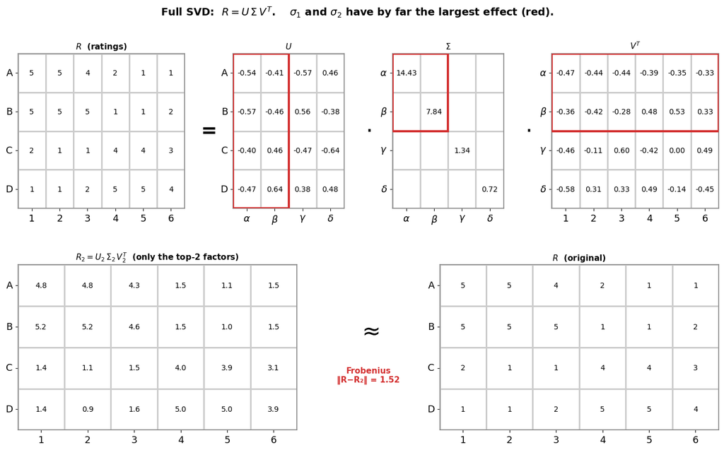

```
σ = [14.43  7.84  1.34  0.72].  Keep σ₁,σ₂=(14.4,7.8), drop σ₃,σ₄=(1.3,0.7) → R₂ rebuilds R with error 1.52.
```

## From three matrices to two: $R \approx P\,Q^{T}$

**Fold $\Sigma$ in** — absorb the stretch into the two sides:

$$\underbrace{U_{k}\Sigma_{k}}_{P}\;\cdot\;\underbrace{V_{k}^{T}}_{Q^{T}} \;=\; P\,Q^{T}\;\approx\;R \qquad\Longrightarrow\qquad \hat r_{ui} \;=\; \vec p_u \cdot \vec q_i$$

Every **user is a row $\vec p_u$ of $P$**, every **item a column $\vec q_i$ of $Q^{T}$** — short vectors in one shared $k$-dim space: the **embeddings**. One rating = one **dot product**.

*($P,Q$ is the standard recommender notation. Folding $\Sigma$ in means $P=U\Sigma$ is no longer orthonormal.)*

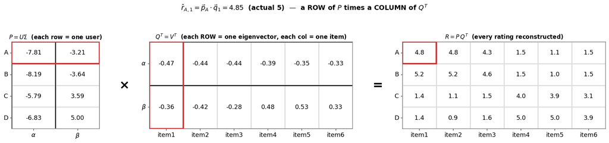

```
Three matrices became two. Row A of P · column 1 of Qᵀ = the (A,1) entry of R = P·Qᵀ.
```

## The catch: SVD needs a *full* matrix

Real rating matrices are **mostly empty**, and plain SVD has no notion of "missing". The textbook hack: **set every unknown to 0** — but **0 means "hated it", not "unseen"**, so the factorization bends to fit millions of fake zeros.

**The fix:** fit *only the observed* cells, plus **regularization** to stop the few ratings overfitting:

$$\min_{P,\,Q}\;\sum_{(u,i)\,\in\,\text{observed}} \big(r_{ui} - \mu - \vec{p}_u\cdot\vec{q}_i\big)^2 \;+\; \lambda\Big(\sum_u\lVert\vec{p}_u\rVert^2 + \sum_i\lVert\vec{q}_i\rVert^2\Big)$$

($\mu$ = global average, subtracted first.) No closed form → **Gradient Descent** or **ALS**.

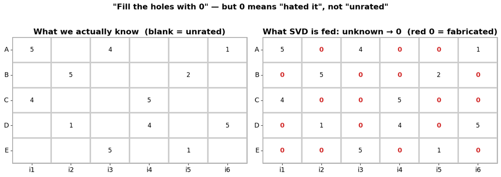

```
18 of 30 cells were unknown — all silently turned into "0 stars".
```

## How do we minimize it? Gradient descent

No closed form anymore — so **roll downhill**. For a function $f(x)$, repeatedly step **against the slope**:

$$x \;\leftarrow\; x \;-\; \alpha\,\frac{\partial f}{\partial x}$$

$\alpha$ is the **learning rate**. A steep slope → a big step; at the bottom the slope is $0$ and we stop.

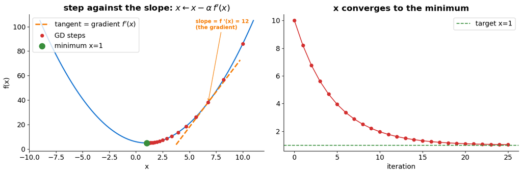

```
Started at x=10; after 25 steps x=1.034 (true minimum 1), learning rate α=0.1.
```

## The same recipe, applied to *our* loss

For one observed rating $r_{ui}$ (taking $r$ as already mean-centred):

**① error** $\;\; e_{ui}=r_{ui}-\vec p_u\cdot\vec q_i$   **② loss** $\;\; J = e_{ui}^{\,2} + \lambda(\lVert\vec p_u\rVert^2+\lVert\vec q_i\rVert^2)$

**③ slope** — each factor gets its own gradient (chain rule): $$\dfrac{\partial J}{\partial \vec p_u}= -2 e_{ui}\,\vec q_i+2\lambda\,\vec p_u,\qquad \dfrac{\partial J}{\partial \vec q_i}= -2 e_{ui}\,\vec p_u+2\lambda\,\vec q_i$$ **④ step downhill** (fold the 2 into $\alpha$): $$\boxed{\;\vec p_u \leftarrow \vec p_u + \alpha\,(e_{ui}\,\vec q_i - \lambda\,\vec p_u)\;}\qquad \vec q_i \leftarrow \vec q_i + \alpha\,(e_{ui}\,\vec p_u - \lambda\,\vec q_i)$$

Under-predicted ($e>0$)? Nudge $\vec p_u$ **toward** $\vec q_i$, by $\propto$ the error. The $-\lambda\vec p_u$ keeps vectors small (no overfit).

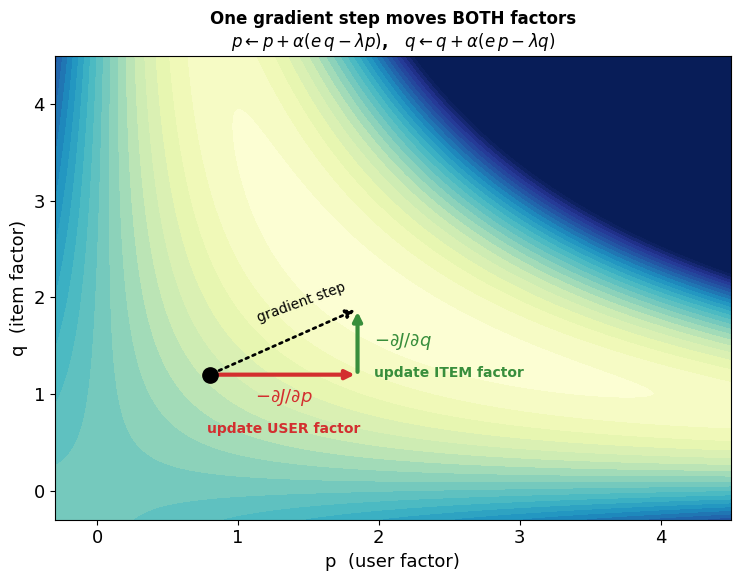

```
At (p,q)=(0.8,1.2): error e=3.04. The downhill step has a p-part (user) AND a q-part (item) — both update together.
```

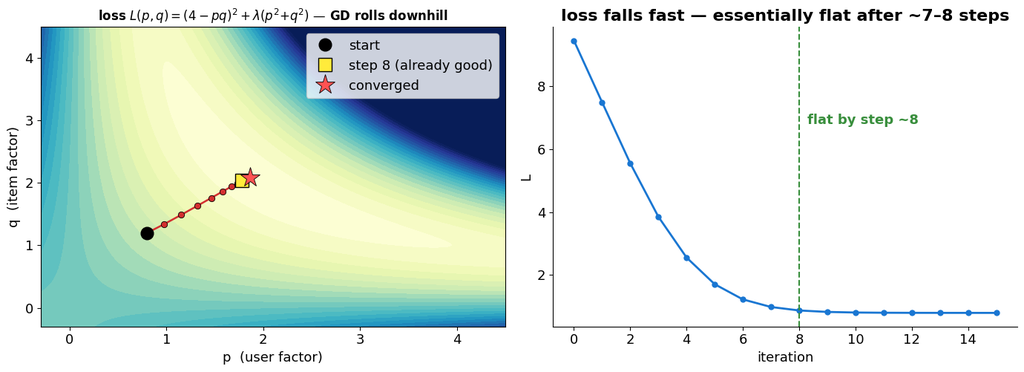

```
p·q = 3.62 by step 8, 3.89 at the end ≈ r = 4 (slightly below 4 because the λ penalty keeps the vectors small).
```

## Putting it together: fill the whole sparse matrix

The **same update, swept over every observed cell**, factorises a real matrix with holes. Start from **random** $P,Q$; gradient-descend on the **observed** ratings only; then read off $\hat R = P\,Q^{T}$:

1. **learn** $P,Q$ — random → after $n$ sweeps $P Q^{T}$ matches $R$ on the knowns;
2. **predict** $\hat R$, rounded to $1\text{–}5$ — knowns reproduced, **holes filled**.

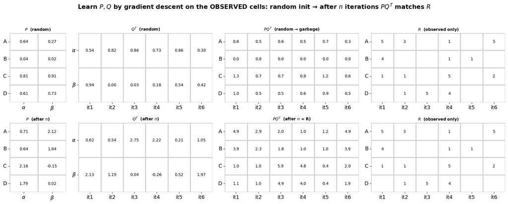

```
RMSE on the observed cells after 4000 sweeps: 0.070.
```

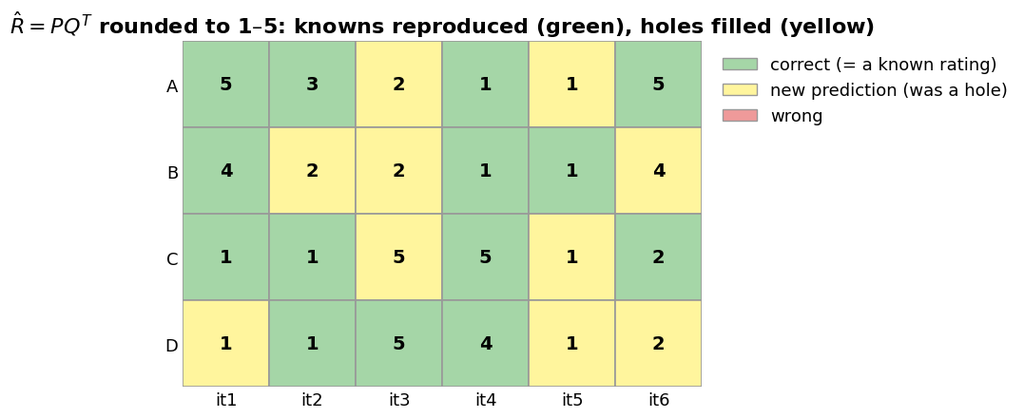

```
Every one of the 10 empty cells now has a 1–5 prediction — the recommender can rank them.
```

## The other optimizer: Alternating Least Squares (ALS)

Gradient descent takes thousands of tiny steps. **ALS** is the shortcut: the loss is hard in $P$ **and** $Q$ together, but **fix one and it's an ordinary least-squares problem** in the other.

- Hold $Q$ fixed → solving each user's $\vec{p}_u$ is **ridge regression** — one *exact* closed-form solve.
- Then hold $P$ fixed → solve every $\vec{q}_i$. **Repeat.**

Each step is exact, so it converges in a **handful of alternations**, and every user (and item) solves **independently → embarrassingly parallel**. That's why ALS is the workhorse for huge implicit-feedback datasets (Spark MLlib, `implicit`).

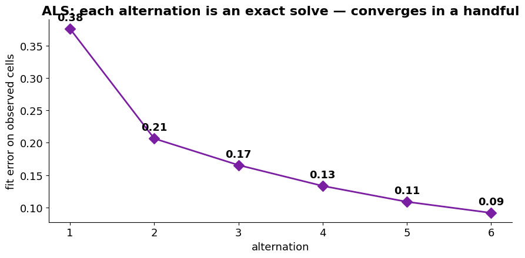

[output not shown]

## Going non-linear: the Autoencoder (your first neural net)

Deep learning in one line: **layers of "multiply by a matrix, then bend"** — $x \to \sigma(W_1 x) \to \sigma(W_2\,\cdot)\to\dots$ Each $W$ is linear (like MF); each activation $\sigma$ (ReLU, sigmoid) **bends** it, so the stack does more than one matrix can.

An **autoencoder** compresses and rebuilds:

- **encoder** squeezes a rating vector to a small **bottleneck**,
- **decoder** rebuilds the full vector,
- trained on the **observed** ratings only.

The bottleneck **is the embedding** (like SVD's $k$ factors, but it can *bend*). This is **AutoRec** — strip every $\sigma$ and it collapses back to **MF**.

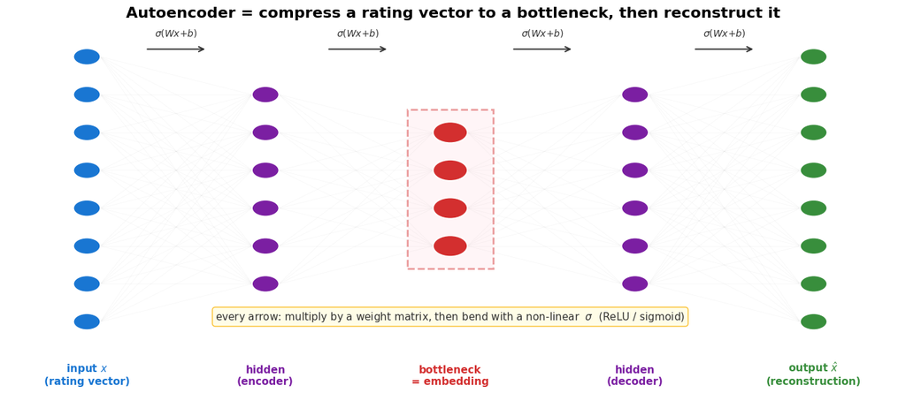

[output not shown]

## Why "non-linear"? The activation functions

Stack two linear layers and you get $W_2(W_1x)=(W_2W_1)x$ — **still one linear map**, no more powerful than MF. The **activation** wedged between them is what unlocks new shapes: ReLU $\max(0,x)$, sigmoid, $\tanh$. A single hidden layer of ReLUs can already bend into essentially *any* curve.

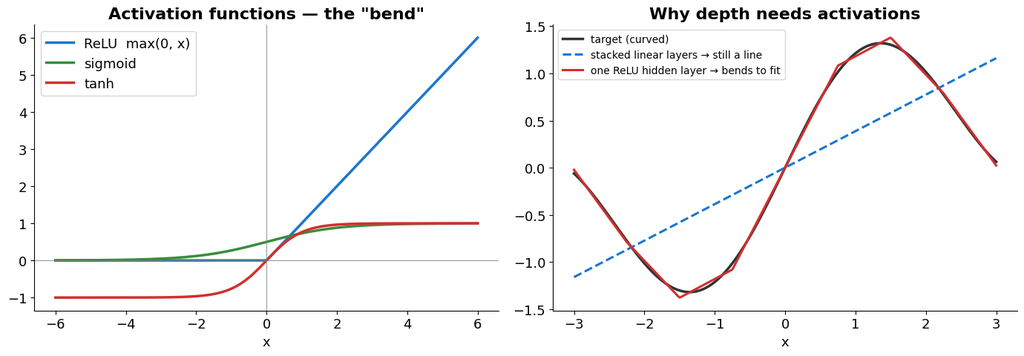

```
No activation → depth buys nothing (W₂W₁ is one matrix). Add σ → the network can model interactions MF cannot.
```

## The pay-off: autoencoder vs. matrix factorization

Fair test: **hide a random 10%** of ratings, train both on the rest, predict the hidden ones, score **RMSE** (lower = better). Two clean code blocks — **MF** (a library) and the **autoencoder** (PyTorch) — each with a table of *the rating we hid* vs *what the model guessed*.

### Model 1 — Matrix Factorization (`SVD` via the Surprise library, with the from-scratch version beside it)

```python
# Matrix factorization two ways — both learn a k-dim vector for every user & every movie from the 90%.

# (a) the easy way: the Surprise library wraps the whole SVD recipe in a few lines.
#     (it also fits per-user/per-item bias terms and uses k=50, so it scores a little better than the
#      plain k=40, no-bias version in (b) — that gap is the biases, not a different algorithm.)
from surprise import SVD, Dataset, Reader
reader = Reader(rating_scale=(0.5, 5.0))
trainset = Dataset.load_from_df(train_df[['userId', 'movieId', 'rating']], reader).build_full_trainset()
mf = SVD(n_factors=50, n_epochs=30, random_state=42).fit(trainset)
mf_pred = np.array([mf.predict(u, i).est for u, i in zip(test_df['userId'], test_df['movieId'])])

# (b) the same thing from scratch (for information): exactly the SGD we derived, r̂ = μ + p·q.
mu = train_df['rating'].mean()
P = np.random.normal(0, 0.1, (n_users, 40))                     # one 40-dim vector per user
Q = np.random.normal(0, 0.1, (n_movies, 40))                    # one 40-dim vector per movie
for epoch in range(15):
    for u, i, r in zip(train_df['user_idx'], train_df['movie_idx'], train_df['rating']):
        e = r - (mu + P[u] @ Q[i])                              # ① error
        P[u] += 0.01 * (e * Q[i] - 0.05 * P[u])                 # ④ the update rule (user, then item)
        Q[i] += 0.01 * (e * P[u] - 0.05 * Q[i])
np_pred = mu + (P[test_df['user_idx'].values] * Q[test_df['movie_idx'].values]).sum(1)

mf_rmse = np.sqrt(np.mean((mf_pred - y_true) ** 2))             # we use the library version below
np_rmse = np.sqrt(np.mean((np_pred - y_true) ** 2))
print(f'MF test RMSE  —  Surprise library: {mf_rmse:.3f}   |   from-scratch numpy (μ + p·q): {np_rmse:.3f}')
```

```
MF test RMSE  —  Surprise library: 0.883   |   from-scratch numpy (μ + p·q): 0.910
```

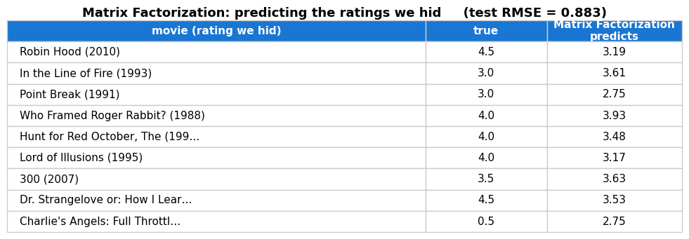

### Model 2 — Autoencoder (`AutoRec` in PyTorch)

```python
# Autoencoder (AutoRec) in PyTorch: feed each movie's rating column, reconstruct it; the bottleneck bends.
import torch
import torch.nn as nn
torch.manual_seed(0)

X = torch.tensor(Rtr.T)                 # one row per MOVIE = its ratings from all users
seen = (X > 0).float()                  # 1 where a rating exists

class AutoRec(nn.Module):
    def __init__(self, n_users, hidden=500):
        super().__init__()
        self.net = nn.Sequential(
            nn.Dropout(0.5),                                  # "denoising": hide half the inputs while training
            nn.Linear(n_users, hidden), nn.Sigmoid(),        # encode  + non-linear activation σ
            nn.Linear(hidden, n_users))                      # decode back to a full rating column
    def forward(self, x):
        return self.net(x)

ae = AutoRec(n_users)
opt = torch.optim.Adam(ae.parameters(), lr=3e-3, weight_decay=1e-4)
for epoch in range(350):
    loss = (((ae(X) - X) ** 2) * seen).sum() / seen.sum()    # error on observed cells only
    opt.zero_grad(); loss.backward(); opt.step()

ae.eval()
with torch.no_grad():
    recon = ae(X).numpy().T                                  # reconstructed full matrix (users x movies)
ae_pred = recon[test_df['user_idx'].values, test_df['movie_idx'].values]
ae_rmse = np.sqrt(np.mean((ae_pred - y_true) ** 2))
print(f'Autoencoder — test RMSE on the hidden ratings: {ae_rmse:.3f}')
```

```
Autoencoder — test RMSE on the hidden ratings: 0.835
```

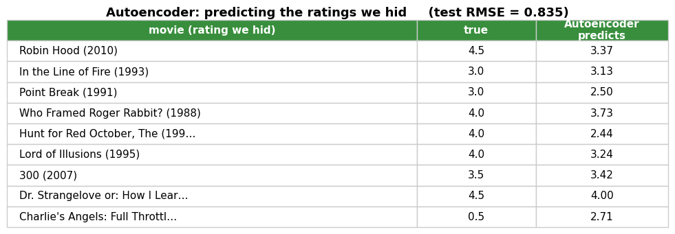

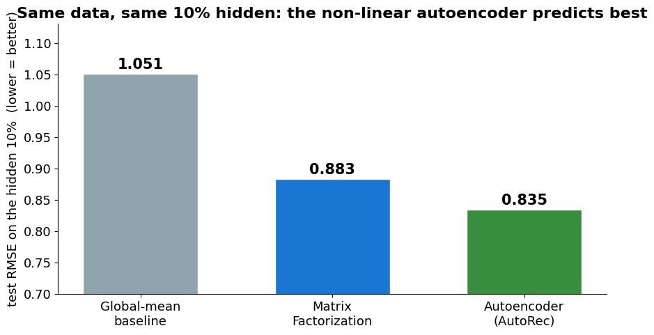

```
baseline 1.051  →  MF 0.883  →  AutoRec 0.835   (AutoRec beats MF by 5%).  Illustrative, not a capacity-matched benchmark — the AE has more parameters (500 hidden + dropout).
```

## The bridge to Session 9 — the cold-start wall

- **Transductive** = the model only knows the **IDs it trained on**.
- **Inductive** = a **function** that makes a vector for **any** input, even an unseen one.

**MF is fully transductive:** a user/movie *is* a learned row — a brand-new ID has no row, so **you must retrain**.

**AutoRec goes half a step further:** it eats a *rating vector*. We feed it each **movie's** ratings (so the input width is the **user list**), and a **new movie that already has a few ratings** gets predictions in one forward pass — no retraining. But a brand-new **user**, or a movie with **zero ratings**, still cold-starts.

The real fix builds the vector from **content** (title, plot, poster) — so even a movie with **zero ratings** gets an embedding. That inductive leap is **Session 9 (Sentence Transformers)**: *data → vectors → latent space → retrieval.*

## Key Takeaways

1. **Two roads:** predict a cell (**Bayes** — a number) vs. **learn vectors** (embeddings).
2. **Matrix factorization** $R \approx P\,Q^{T}$ — users & items in **one shared space**.
3. **SVD** is the optimal linear factorization, but needs a full matrix; filling holes with 0 is biased.
4. **Gradient Descent & ALS** fit on **observed ratings only** (+ regularization) — same goal, two optimizers.
5. The rows of $P, Q$ are **embeddings** — cosine similarity (Session 7) now applies to *learned* vectors.
6. **Autoencoders** are the non-linear upgrade — the activation $\sigma$ lets them **beat MF** on held-out ratings.
7. **Transductive → cold start.** Next: **inductive** neural embeddings (Session 9).

**→ Now switch to the practice notebook: SVD & SGD from scratch, then build an AutoRec.**